# Project4_TsarinaPatnaik

Tsarina Patnaik

2022-12-05

```r
#Setting up libraries for Project 1
library(readxl)
library(rmarkdown)
library(tidyverse)
library(dplyr)
library(DT)
library(pander)
library(RColorBrewer)
library(rio)
library(magrittr)
library(knitr)
library(ggplot2)
library(dbplyr)
library(psych)
library(FSA)
library(kableExtra)
library(devtools)
library(plyr)

#Importing the dataset for Project 1
dataset4 <- read_excel("~/Desktop/ALY6010_R_Project/Project4_TsarinaPatnaik/lizards_project4.xlsx")
```

**ALY6010 Probability and Statistical Theory**  
**Northeastern University**  
Tsarina Patnaik  
Date: 5th December, 2022  
**Project 4 Report: Applications of Different Hypothesis Tests for 2 Sample Comparisons**  
Instructor: Dr. Dee Chiluiza, PhD

**INTRODUCTION**  
**1. What is Hypothesis Testing?** A type of statistical analysis known as hypothesis testing uses data from a sample to make inferences about a population parameter or probability distribution.  
**Hypothesis Testing in Healthcare:** Evidence-based medicine is frequently used by healthcare professionals as a practical decision-making tool. A research hypothesis is often tested, and the findings are usually presented using p values, confidence intervals, or both. The scientists also estimate or determine the statistical or scientific significance.  
For eg. The predictor would be whether or not a person drinks chocolate, and the outcome would be having type II diabetes, if your hypothesis, for example, was that “Chocolate intake is connected to type II diabetes.” A solid theory would also be specific. This means that it should be clear who will be involved and how the study will be conducted in order to evaluate the hypothesis. According to a questionnaire completed over the course of a year, individuals are more likely to develop type II diabetes than those who consume less than 10 grams of milk chocolate daily.

**2. Applications of z-test, f-test and t-test:**  
Whether or not you are aware of the population standard deviation, a z-test may be used to test a population’s mean against a standard or to compare the means of two populations when working with large (n 30) samples. Additionally, it is used to compare the proportions of two populations or to evaluate the percentage of a certain trait against a reference proportion. Using the average engineering salaries of men and women as an example  
Comparing the percentage of defectives from two production lines, for instance.  
If you do not know the standard deviation of the populations and you have a small sample size (n 30), you can use a t-test to compare the means of two populations or test the mean of one population against a standard.  
When working with large (n 30) samples, a z-test may be used to compare the means of two populations or test a population’s mean against a standard, whether or not you are aware of the population standard deviation. It is also used to assess the percentage of a certain attribute in comparison to a reference % or to compare the proportions of two populations. As an illustration, let’s look at the average engineering salaries for men and women.  
Comparing the percentage of defectives from two production lines, for instance.  
If you do not know the standard deviation of the populations and you have a small sample size (n 30), you can use a t-test to compare the means of two populations or test the mean of one population against a standard.

**3. Importance of Using Academic References:**  
References play a significant role in academic writing. It contextualizes your work, exemplifies the range and depth of your study, and recognizes the contributions of others. Every time you borrow an idea from someone else, give credit.  
-helps you prevent plagiarism by making it apparent which ideas are your own and which are the work of others;  
-demonstrates your command of the subject;  
-provides support for your thoughts, arguments, and opinions;  
-and enables others to determine the sources you have consulted.

**4. Dataset Description:**  
The Lizards Dataset used for this project describes the Length and Heart Rate of both male and female lizards. Furthermore, for the purpose of analysis, a gender-wise subset has been created for male and female lizards.

**Task 1**  
**To find the basic descriptive statistics**  
**Description:** In this task I have used this open question to use my knowledge on the basic descriptive statistics to plot some visualizations and draw some conclusions from the given dataset

```r
#Task 1

dataset4 %>%
  dplyr::select(Length, HeartRate)%>%
  psych::describe() %>%
  round(2) %>%
  t() %>%
   kbl(caption = "Table.1.1.Basic Descriptive Statistics for Length and HeartRate in Lizards",
      font_size = 12,
      align = "c",
      position ='center',
      digits = 2) %>%
  kable_classic(full_width = T,
                font_size = 12)
```

Table.1.1.Basic Descriptive Statistics for Length and HeartRate in Lizards

|  | Length | HeartRate |
| --- | --- | --- |
| vars | 1.00 | 2.00 |
| n | 120.00 | 120.00 |
| mean | 21.19 | 2.62 |
| sd | 1.46 | 0.55 |
| median | 21.15 | 2.61 |
| trimmed | 21.21 | 2.63 |
| mad | 1.49 | 0.52 |
| min | 17.59 | 1.07 |
| max | 24.60 | 3.81 |
| range | 7.01 | 2.74 |
| skew | -0.11 | -0.19 |
| kurtosis | -0.46 | 0.08 |
| se | 0.13 | 0.05 |

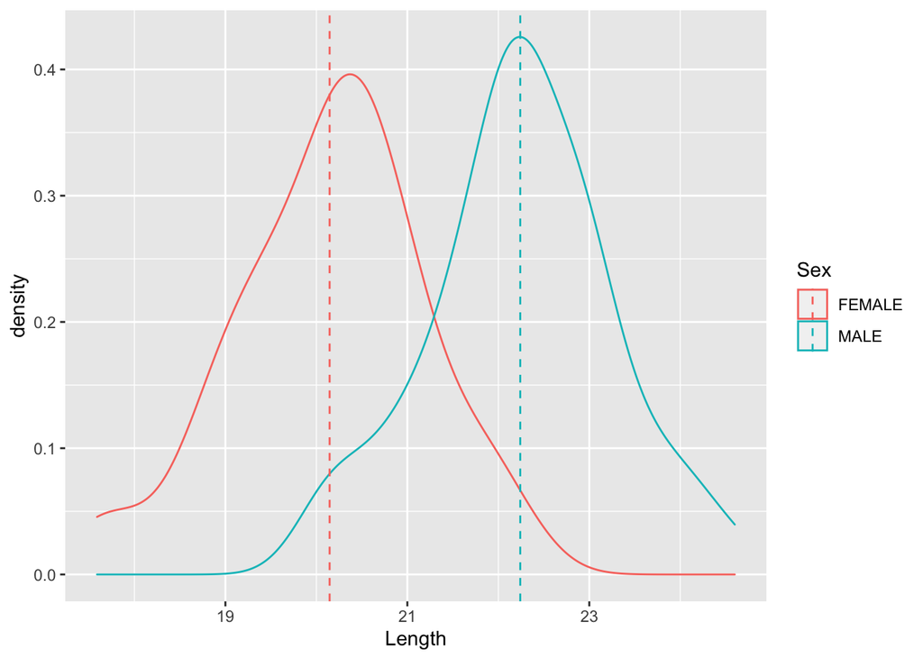

```r
# 1. Density plot to check the mean lengths of lizards in male and female lizards when compared to one another

mu <- ddply(dataset4, "Sex", summarise, grp.mean = mean(Length))
# Add mean lines
Length_density_plot <- ggplot(dataset4, aes(x=Length, color=Sex)) +
  geom_density() + geom_vline(data=mu, aes(xintercept = grp.mean, color=Sex),
             linetype="dashed")
Length_density_plot
```

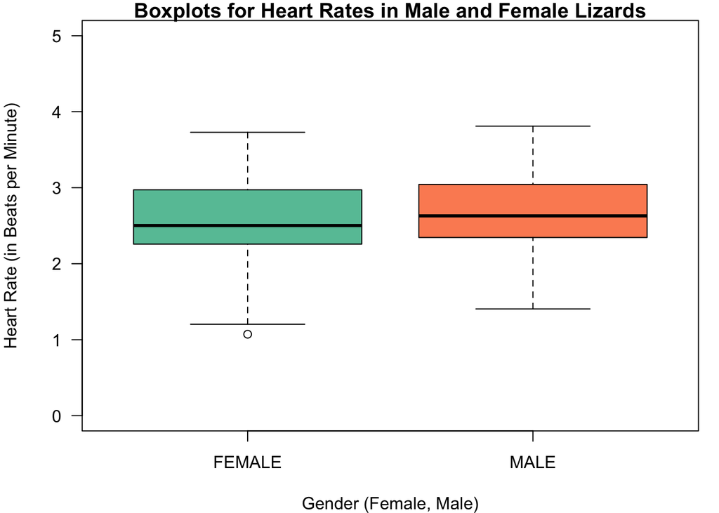

```r
# 2. Boxplot for Heart Rates for Male and Female Lizards

par(mai=c(1, 1, 0.3,0.2), mar=c(4,4,1,1))
box2 = boxplot(dataset4$HeartRate ~ dataset4$Sex,
               las=1,
        col = brewer.pal(4,"Set2"),
        ylim = c(0,5),
        align = "c",
        main = "Boxplots for Heart Rates in Male and Female Lizards",
        xlab = "Gender (Female, Male)",
        ylab = "Heart Rate (in Beats per Minute)")
```

**Methodology Task 1:**  
For the above performed task, I used the psych::describe() to derive the basic descriptive statistics for the given dataset. Though this, I was able to get a good look at the dataset being dealth with. After that, I plotted a density plot for the lengths for the male and female lizards. I also pltted a box plot for the heart rated in male and female lizards.  
**Observations from Task 1:**  
It is clear from the density plot that the mean for male lizard lengths is 22.24 and the mean for female is 20.14. It can be concluded that the male lizards have a larger length than the females. Also, through the boxplot, the distribution of the heart rate data can be seen.

**Task 2**  
**Testing Difference Between Two Means: Using z Test for Independent Samples**  
**Description:** In this task, I have performed hypotheses testing for the difference between 2 means using the z Test for 2 independent samples.  
the two hypotheses here in question are:

H0 (Null Hypothesis) = male and female lizards have same length

**μ Sample 1 = μ Sample 2**

H1 = male and female lizards don’t have same length

**μ Sample 1 ≠ μ Sample 2**

```r
#Task 2
a = 0.01
male_var = 1.34
female_var = 1.18

#subsets
male = subset(dataset4, subset=(dataset4$Sex =="MALE"),  na.rm = TRUE)
female = subset(dataset4, subset=(dataset4$Sex =="FEMALE"),  na.rm = TRUE)

#Lengths
n1 = length(male$Length)
n2 = length(female$Length)

#Finding Means
mean_male = mean(male$Length)
mean_female = mean(female$Length)

#Differenc between means
mean_diff_2 = mean_male - mean_female
denom = sqrt(((male_var)/n1)+((female_var)/n2))

#Critical Value
crit_val_1 = qnorm(1-a,n2-1)
z_test_value = ((mean_diff_2 - 0)/(denom))

Critical_Value_Left = qnorm(a/2)
Critical_Value_Right = qnorm(1- (a/2))

#P Value
pval = round(1-pnorm(z_test_value), digits = 3)

#Populating the table
rownum = c("Sample size of male Lizards Length","Sample size of female Lizards Length","Male Lizard Length Mean","Female Lizard Length Mean","Male Lizards Variance","Female Lizards Variance","Alpha","Critical Left Value", "Critical Right Value", "Test Value", "P Value")

column = c("Values")

length_table_1 = matrix(c(n1, n2, mean_male, mean_female, male_var, female_var, a, Critical_Value_Left, Critical_Value_Right, z_test_value, pval),
                     nrow = 11,
                     byrow = TRUE,
                     ncol = 1)

colnames(length_table_1) = column
rownames(length_table_1) = rownum

length_table_1 %>%
  kbl(caption = "Table.2.1.Hypothesis Test Results for difference between 2 means using z-test",
      font_size = 12,
      align = "c",
      position ='center',
      digits = 2) %>%
  kable_classic(full_width = T,
                font_size = 12)
```

Table.2.1.Hypothesis Test Results for difference between 2 means using z-test

|  | Values |
| --- | --- |
| Sample size of male Lizards Length | 60.00 |
| Sample size of female Lizards Length | 60.00 |
| Male Lizard Length Mean | 22.24 |
| Female Lizard Length Mean | 20.15 |
| Male Lizards Variance | 1.34 |
| Female Lizards Variance | 1.18 |
| Alpha | 0.01 |
| Critical Left Value | -2.58 |
| Critical Right Value | 2.58 |
| Test Value | 10.22 |
| P Value | 0.00 |

**Task 3**  
**Testing the Difference Between Two Variances**  
**Description:** In this task, I have performed hypotheses testing for testing the difference between 2 variances.  
the two hypotheses here in question are:

H0 (Null Hypothesis) = male length variance is euql to female length variance

**μ Sample 1 = μ Sample 2**

H1 = female length variance > male length variance

**μ Sample 1 ≠ μ Sample 2**

```r
#Task 3
female_var3 = var(female$Length)
male_var3 = var(male$Length)

#Performing the f test
f_test1 = female_var/male_var

#Critical value
fdf1 = n2-1
mdf1 = n1-1
alpha3 = 0.01
a3 = alpha3/2

left1 = (alpha3/2)
right1 = (1-alpha3/2)

#define F critical values
f_lower = qf(alpha3/2, fdf1, mdf1)
f_upper = 1/qf(alpha3/2, fdf1, mdf1)

#CI
cvleft3 = f_test1*f_lower
cvright3 = f_test1*f_upper

#F Critical one-tail
critF <- qf(alpha3, fdf1, mdf1,lower.tail=FALSE)

#P Value
pvalue2 = pf(f_test1, fdf1, mdf1, lower.tail = FALSE)

#Populating the table
rownum = c("Sample size of male Lizards Length","Sample size of female Lizards Length","Male Lizard Length Variance","Female Lizard Length Variance","Alpha","Critical Left Value", "Critical Right Value", "Critical Value One-Tail", "Test Value", "P Value")

column = c("Values")

var_table_3 = matrix(c(n1, n2, male_var3, female_var3, alpha3, cvleft3, cvright3, critF, f_test1, pvalue2),
                     nrow = 10,
                     byrow = TRUE,
                     ncol = 1)

colnames(var_table_3) = column
rownames(var_table_3) = rownum

var_table_3 %>%
  kbl(caption = "Table.3.1.Hypothesis Test Results for the difference between 2 Variances using f-test",
      font_size = 12,
      align = "c",
      position ='center',
      digits = 2) %>%
  kable_classic(full_width = T,
                font_size = 12)
```

Table.3.1.Hypothesis Test Results for the difference between 2 Variances using f-test

|  | Values |
| --- | --- |
| Sample size of male Lizards Length | 60.00 |
| Sample size of female Lizards Length | 60.00 |
| Male Lizard Length Variance | 1.01 |
| Female Lizard Length Variance | 1.08 |
| Alpha | 0.01 |
| Critical Left Value | 0.45 |
| Critical Right Value | 1.74 |
| Critical Value One-Tail | 1.85 |
| Test Value | 0.88 |
| P Value | 0.69 |

**Task 4**  
**Testing to find that the mean heart rate is not equal for Male anad Female Lizards**  
**Description:** In this task, I have performed hypotheses testing to find if the male and female lizards have the same mean hear rates or not.  
the two hypotheses here in question are:

**μ Sample 1 = μ Sample 2**

**μ Sample 1 ≠ μ Sample 2**

```r
#Task 4
hr_male_var = 0.34
hr_female_var = 0.3
Alpha=0.01

Male_hr <- subset(dataset4$HeartRate,subset=(dataset4$Sex=="MALE"),  na.rm = TRUE)
Female_hr <- subset(dataset4$HeartRate,subset=(dataset4$Sex=="FEMALE"),  na.rm = TRUE)

mean_male_hr = mean(Male_hr)
mean_female_hr = mean(Female_hr)


n1_hr = length(Male_hr)
n2_hr = length(Female_hr)

#As female sample size is smaller than the male sample size we will use n2Bpm-1 in our formula
CV_hr = qt(1-Alpha,n2_hr-1)

t_test_val_hr = ((mean_male_hr-mean_female_hr)-0)/(sqrt((hr_male_var/n1_hr)+(hr_female_var/Female_hr)))


#Populating the table
rownum = c("Sample size of male Lizards Heart rate","Sample size of female Lizards Heart rate","Male Lizard Heart rate Mean","Female Lizard Heart rate Mean","Male Lizards Variance","Female Lizards Variance","Alpha","Critical Value","Test Value")

column = c("Values")

hr_table_4 = matrix(c(n1_hr, n2_hr, mean_male_hr, mean_female_hr, hr_male_var, hr_female_var, Alpha, CV_hr, t_test_val_hr),
                     nrow = 9,
                     byrow = TRUE,
                     ncol = 1)

colnames(hr_table_4) = column
rownames(hr_table_4) = rownum

hr_table_4 %>%
  kbl(caption = "Table.4.1 Hypothesis Test Results",
      font_size = 12,
      align = "c",
      position ='center',
      digits = 2) %>%
  kable_classic(full_width = T,
                font_size = 12)
```

Table.4.1 Hypothesis Test Results

|  | Values |
| --- | --- |
| Sample size of male Lizards Heart rate | 60.00 |
| Sample size of female Lizards Heart rate | 60.00 |
| Male Lizard Heart rate Mean | 2.70 |
| Female Lizard Heart rate Mean | 2.54 |
| Male Lizards Variance | 0.34 |
| Female Lizards Variance | 0.30 |
| Alpha | 0.01 |
| Critical Value | 2.39 |
| Test Value | 0.46 |

```r
#Task 5
female_var5 = var(female$HeartRate)
male_var5 = var(male$HeartRate)

#Performing the f test
f_test5 = female_var5/male_var5

#Critical value
fdf5 = n2-1
mdf5 = n1-1
alpha5 = 0.01
a5 = alpha5/2

left5 = (alpha5/2)
right5 = (1-alpha5/2)

#define F critical values
f_lower5 = qf(alpha5/2, fdf5, mdf5)
f_upper5 = 1/qf(alpha5/2, fdf5, mdf5)

#CI
cvleft5 = f_test5*f_lower5
cvright5 = f_test5*f_upper5

#F Critical one-tail
critF5 <- qf(alpha5, fdf5, mdf5,lower.tail=FALSE)

#P Value
pvalue5 = pf(f_test5, fdf5, mdf5, lower.tail = FALSE)

#Populating the table
rownum = c("Sample size of male Lizards Heart Rate","Sample size of female Lizards Heart Rate","Male Lizard Heart Rate Variance","Female Lizard Heart Rate Variance","Alpha","Critical Left Value", "Critical Right Value", "Critical Value One-Tail", "Test Value", "P Value")

column = c("Values")

var_table_5 = matrix(c(n1, n1, male_var5, female_var5, alpha5, cvleft5, cvright5, critF5, f_test5, pvalue5),
                     nrow = 10,
                     byrow = TRUE,
                     ncol = 1)

colnames(var_table_5) = column
rownames(var_table_5) = rownum

var_table_5 %>%
  kbl(caption = "Table.5.1.Hypothesis Test Results for the difference between 2 Variances using f-test",
      font_size = 12,
      align = "c",
      position ='center',
      digits = 2) %>%
  kable_classic(full_width = T,
                font_size = 12)
```

Table.5.1.Hypothesis Test Results for the difference between 2 Variances using f-test

|  | Values |
| --- | --- |
| Sample size of male Lizards Heart Rate | 60.00 |
| Sample size of female Lizards Heart Rate | 60.00 |
| Male Lizard Heart Rate Variance | 0.25 |
| Female Lizard Heart Rate Variance | 0.34 |
| Alpha | 0.01 |
| Critical Left Value | 0.69 |
| Critical Right Value | 2.69 |
| Critical Value One-Tail | 1.85 |
| Test Value | 1.36 |
| P Value | 0.12 |

**Task 6**  
**To test if meditation has an effect on sleep quality or not:**  
**Description:**  
In the following task, I have used hypotheses testing on two dependent samples with number of observations = 12 (n<30), to find whether meditation has an effect on sleep quality or not.

```r
# Task 6
alpha = 0.01
n6 = 12
dof6 = n6-1
cv = 2.576

#Data Set
dat1 = c(5.7, 7.8, 5.9, 5.6, 5.9, 6.8, 5.7, 3.9, 4.6, 4.5, 7.7, 6.3)
dat2 = c(6.8, 8.7, 7.6, 6.2, 6.1, 7.7, 5.9, 4.5, 6.5, 6.1, 6.9, 9.2)

diff_vector = (dat1 - dat2)
mean_diff_vector = mean(diff_vector)
diff_vector_square = diff_vector^2

sum_diff_vector_square = sum(diff_vector_square)
sum_diff_vector = sum(diff_vector)

sd_diff = sqrt(((n6*sum_diff_vector_square)-(sum_diff_vector^2))/(n6*dof6))

#Finding Test Value
test_value6 = ((mean_diff_vector-0)/(sd_diff/sqrt(n6)))

#Populating the table for analysis
table_task6_b = matrix(c(dat1, dat2, diff_vector, diff_vector_square), ncol=4, byrow= FALSE)
colnames(table_task6_b) = c("Data1", "Data2", "D=(X1-X2)", "D2=(X1-X2)2")
rownames(table_task6_b) = c("", "", "", "", "", "", "", "", "", "", "", "")

table_task6_bf = round(table_task6_b, 3)

final_table = as.table(table_task6_bf)

final_table %>%
  kbl(caption = "Table.6.1 Analysis Results",
      font_size = 12,
      align = "c",
      position ='center',
      digits = 2) %>%
  kable_classic(full_width = T,
                font_size = 12)
```

Table.6.1 Analysis Results

|  | Data1 | Data2 | D=(X1-X2) | D2=(X1-X2)2 |
| --- | --- | --- | --- | --- |
|  | 5.7 | 6.8 | -1.1 | 1.21 |
|  | 7.8 | 8.7 | -0.9 | 0.81 |
|  | 5.9 | 7.6 | -1.7 | 2.89 |
|  | 5.6 | 6.2 | -0.6 | 0.36 |
|  | 5.9 | 6.1 | -0.2 | 0.04 |
|  | 6.8 | 7.7 | -0.9 | 0.81 |
|  | 5.7 | 5.9 | -0.2 | 0.04 |
|  | 3.9 | 4.5 | -0.6 | 0.36 |
|  | 4.6 | 6.5 | -1.9 | 3.61 |
|  | 4.5 | 6.1 | -1.6 | 2.56 |
|  | 7.7 | 6.9 | 0.8 | 0.64 |
|  | 6.3 | 9.2 | -2.9 | 8.41 |

```r
#Populating the result table
rownum = c("Sample size","Degrees of Freedom","Test Value", "Critical Value")

column = c("Values")

table_6 = matrix(c(n6, dof6, test_value6, cv),
                     nrow = 4,
                     byrow = TRUE,
                     ncol = 1)

colnames(table_6) = column
rownames(table_6) = rownum

table_6 %>%
  kbl(caption = "Table.6.2. Hypothesis Test Results",
      font_size = 12,
      align = "c",
      position ='center',
      digits = 2) %>%
  kable_classic(full_width = T,
                font_size = 12)
```

Table.6.2. Hypothesis Test Results

|  | Values |
| --- | --- |
| Sample size | 12.00 |
| Degrees of Freedom | 11.00 |
| Test Value | -3.55 |
| Critical Value | 2.58 |

**Methodology Task 6:**  
In this task, I have used used the technique of testing between two variables when the two given samples are dependent. With a given alpha value of 0.01 and a total number (n) of 12 observations, I have calculated the difference in means to find the standard deviation for the differences and thereby tested it.  
If the subjects chosen for the first group in any way impacted the subjects chosen for the other group, then two samples would be dependent. Therefore, this is a test of 2 dependent paired samples.  
the two hypotheses here in question are:

**μ Sample 1 = μ Sample 2**

**μ Sample 1 ≠ μ Sample 2**

**CONCLUSION**  
Through this report, I have performed Hypothesis Testing on the given data set. The following are the things I was able to conclude:  
1. I understood the different applications of f-test, z-test and t-test.  
2. Through this project, I was able to understand how to interpret the results of a hypothesis, when to and when not to reject a null hypothesis.  
3. I performed basic descriptive statistics as an open question, that helped me improve my visualization techniques, and allowed me to experiment with codes to present it in a formal manner.

**BIBLIOGRAPHY**  
The following are the references used in this report:  
1. Chiluiza, D. *https://rpubs.com/Dee_Chiluiza/816756* , retrieved on 5th December, 2022  
2. Martin R. Huecker, September 24, 2021. *Hypothesis Testing, P Values, Confidence Intervals, and Significance.* https://www.ncbi.nlm.nih.gov/books/NBK557421/ on 5th December, 2022  
3. B. Rebecca, August 7, 2020, *Understanding Confidence Intervals | Easy Examples & Formulas* https://www.scribbr.com/statistics/confidence-interval/ 5th December, 2022  
4. Enago, September 5, 2006, *Quick Guide to Biostatistics in Clinical Research: Hypothesis Testing* https://www.enago.com/academy/quick-guide-to-biostatistics-in-clinical-research-hypothesis-testing/#:~:text=An%20example%20of%20a%20specific,of%20milk%20chocolate%20per%20day.%E2%80%9D retrieved on 5th December, 2022  
5. B. SAIKRISHNA, June 15, 2013 *Difference between Z-test, F-test, and T-test* https://brandalyzer.blog/2010/12/05/difference-between-z-test-f-test-and-t-test/ retrieved on 5th December, 2022

**APPENDIX**  
I have also attachech my reprt “Project4_TsarinaPatnaik” along with this code.